# Balancing NASA’s Asteroid Dataset and Buiding Models for Predicting Hazard Levels

```r
lm_model <- lm(Hazardous ~ ., data = df)
# Check for linear dependencies
linear_deps <- stats::alias(lm_model)
print(linear_deps)
```

Model : Hazardous ~ Absolute.Magnitude + Est.Dia.in.KM.min. + Est.Dia.in.KM.max. + Est.Dia.in.Feet.min. + Est.Dia.in.Feet.max. + Relative.Velocity.km.per.sec + Miss.Dist..Astronomical. + Miss.Dist..lunar. + Miss.Dist..kilometers. + Orbit.ID + Orbit.Uncertainity + Minimum.Orbit.Intersection + Jupiter.Tisserand.Invariant + Epoch.Osculation + Eccentricity + Semi.Major.Axis + Inclination + Asc.Node.Longitude + Orbital.Period + Perihelion.Distance + Perihelion.Arg + Aphelion.Dist + Perihelion.Time + Mean.Anomaly + Mean.Motion

# check for Multi collinarity and drop it

```r
library(car)
vif_values <- car::vif(lm(Hazardous ~ ., data = reduced_df))

# Identify variables with high VIF
high_vif_vars <- names(vif_values)[vif_values > 5]
# Remove variables with high VIF or high correlation
reduced_df <- df[, !names(df) %in% high_vif_vars]
```

### checking outliers

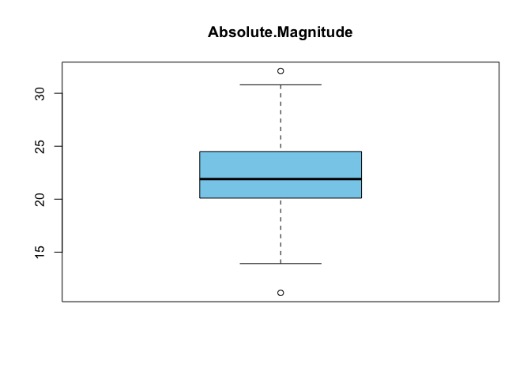

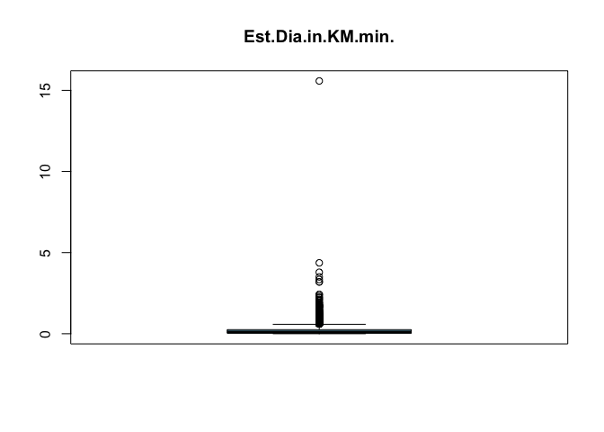

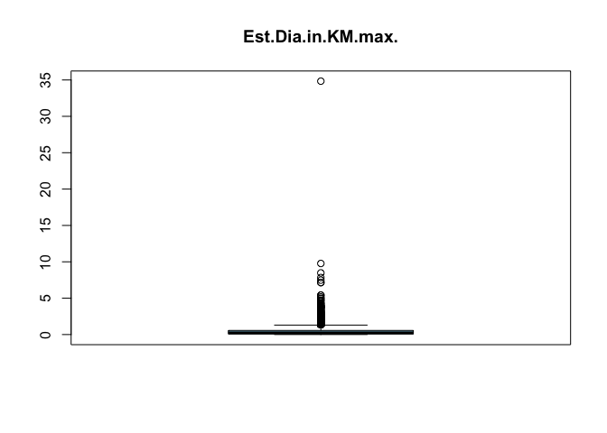

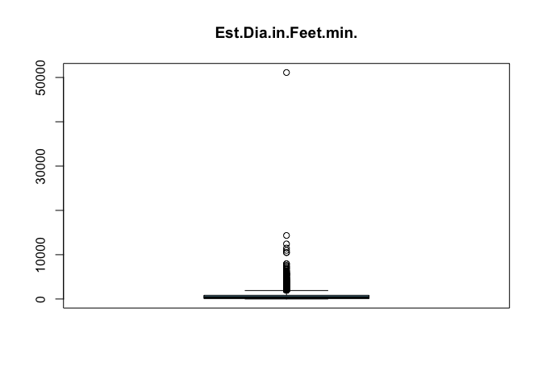

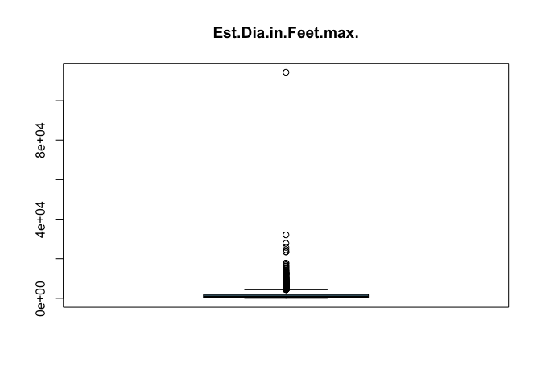

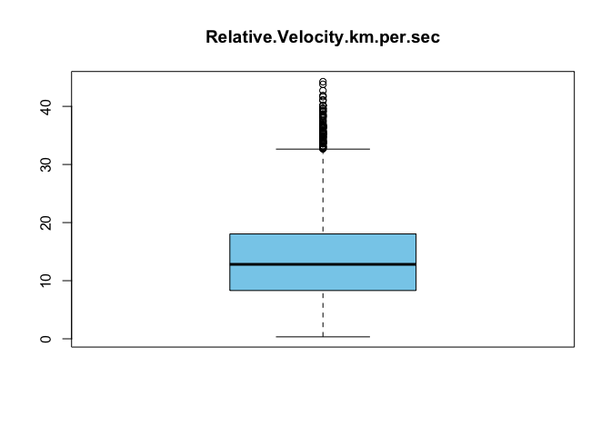

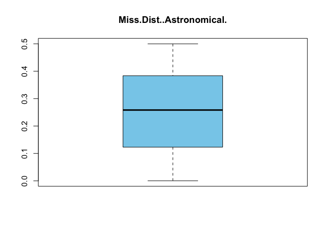

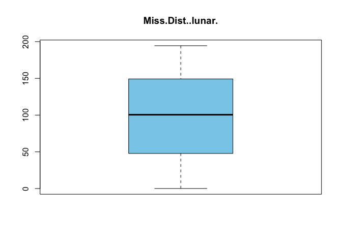

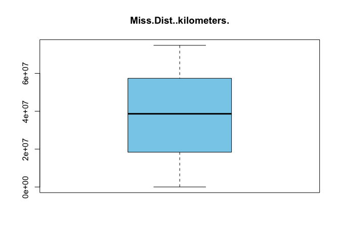

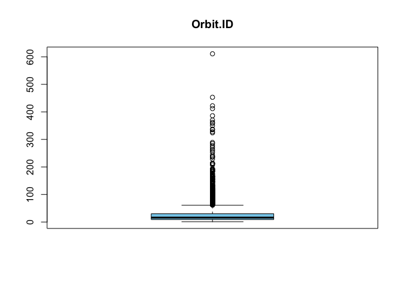

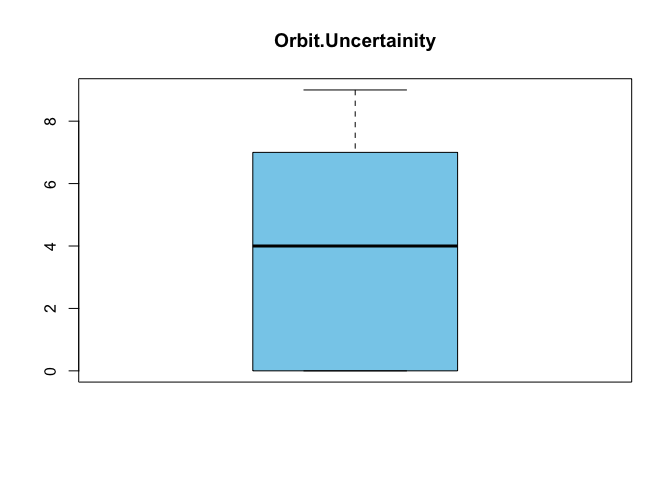

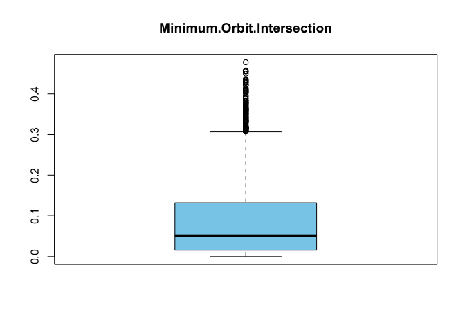

[9 more figures not shown]

```r
columns_to_check <- names(reduced_df)[names(reduced_df) != "Hazardous"]

for (col in columns_to_check) {
  boxplot(reduced_df[[col]], main = col, col = 'skyblue')
}
```

# Romove Outlier

```r
# Function to remove outliers based on IQR
remove_outliers <- function(x) {
  Q1 <- quantile(x, 0.25)
  Q3 <- quantile(x, 0.75)
  IQR_val <- Q3 - Q1
  lower_bound <- Q1 - 1.5 * IQR_val
  upper_bound <- Q3 + 1.5 * IQR_val
  return(ifelse(x >= lower_bound & x <= upper_bound, x, NA))
}

# Loop through columns (except 'Hazardous') and remove outliers
for (col in columns_to_check) {
  reduced_df[[col]] <- remove_outliers(reduced_df[[col]])
}

# Remove rows containing NA values after outlier removal
reduced_df <- reduced_df[complete.cases(reduced_df), ]
reduced_df
```

[output not shown]